# Impact of Immigration on Extreme Right Vote

Adrian Goedeckemeyer

11/12/2016

## Data Preparation

We combine the dataset from Arzheimers study (2009) with data on yearly immigration and percent of population that are foreign that were used in the replication by Javed and Gidron (2011). Parts of the data preparation are similar to their process

```r
require(foreign)
load('~/Downloads/nonimp.RData')
data <- x

##Center variables (done as according to the author).

salienzmean.c <- data$salienzmean - 3.84568
rvar.c <- data$rvar - 21.75423

##Load migration data.

mig.data <- read.csv("~/Downloads/migration.csv")

##Label migration data.

colnames(mig.data) <- c("year","migration","at","be","dk","fi","fr","deo","dew","gr","it","nl","no","pt","es","se","lu","sortcountry")

##Merge migration data with Arzheimer dataset by year and country.

new.data <- merge(data, mig.data, by=c("year","at","be","dk","fi","fr","deo","dew","gr","it","nl","no","pt","es","se","lu","sortcountry"))

##Load foreign population data.

fp.data <- read.csv("~/Downloads/foreign population.csv")

##Merge foreign population data with Arzheimer dataset by year and country.

new.data <- merge(new.data, fp.data, by=c("year", "sortcountry"))

##Create country dummies for merged dataset.

new.data$country <- factor(new.data$sortcountry, labels=c("AT", "BE","DE-E","DE-W","DK","ES","FI","FR","IT","LU","NL","NO","PT","SE"))

### Added check to verify that this works properly
sum(new.data$country[new.data$it==1]!="IT")==0
```

```
## [1] TRUE
```

```r
sum(new.data$country[new.data$deo==1]!="DE-E")==0
```

```
## [1] TRUE
```

## Replicate Regression

As done by the Arzheimer paper, we are running a logistic regression, with the binary variable of extreme right vote as a dependent variable. We are copying their selection of covariates to test their model

```r
## We will test the model used in the paper by using a testset validation approach

set.seed(1)

train <- sample(1:nrow(new.data), nrow(new.data)*.8)
data.test <- new.data[-train,]

glm.fit <- glm(rexvote ~ male + age1 + age2 + age4 + mye1 + mye2 + farmerown + worker + retired + unemployed + zlrs + euschlecht + zsatisdmo + disp + lfed1 + migration + sur + migration:sur + replacementrate + sur:replacementrate + migration:replacementrate + rmax + salienzmean + rvar + rvar:salienzmean + country, family=binomial, data=new.data[train,])

summary(glm.fit)
```

```
##
## Call:
## glm(formula = rexvote ~ male + age1 + age2 + age4 + mye1 + mye2 +
##     farmerown + worker + retired + unemployed + zlrs + euschlecht +
##     zsatisdmo + disp + lfed1 + migration + sur + migration:sur +
##     replacementrate + sur:replacementrate + migration:replacementrate +
##     rmax + salienzmean + rvar + rvar:salienzmean + country, family = binomial,
##     data = new.data[train, ])
##
## Deviance Residuals:
##     Min       1Q   Median       3Q      Max
## -2.3707  -0.2535  -0.1449  -0.0789   3.9337
##
## Coefficients:
##                             Estimate Std. Error z value Pr(>|z|)
## (Intercept)               -5.6484498  0.4915398 -11.491  < 2e-16 ***
## malenein                   0.4717635  0.0340739  13.845  < 2e-16 ***
## age1                       0.3682413  0.0483554   7.615 2.63e-14 ***
## age2                       0.1457219  0.0458793   3.176  0.00149 **
## age4                      -0.1029820  0.0636977  -1.617  0.10594
## mye1                       0.0949986  0.0427007   2.225  0.02610 *
## mye2                      -0.2788926  0.0499847  -5.580 2.41e-08 ***
## farmerown                 -0.0273978  0.0591581  -0.463  0.64327
## worker                     0.4051277  0.0458596   8.834  < 2e-16 ***
## retired                    0.0007096  0.0613183   0.012  0.99077
## unemployed                 0.4573045  0.0663986   6.887 5.69e-12 ***
## zlrs                       0.5482203  0.0084082  65.200  < 2e-16 ***
## euschlecht                 0.7539384  0.0414655  18.182  < 2e-16 ***
## zsatisdmo                  0.6264695  0.0211139  29.671  < 2e-16 ***
## disp                       0.0140045  0.0063784   2.196  0.02812 *
## lfed1                      0.2303720  0.0704648   3.269  0.00108 **
## migration                  0.4495295  0.0411790  10.916  < 2e-16 ***
## sur                        0.1170459  0.0461933   2.534  0.01128 *
## replacementrate            0.0409721  0.0104586   3.918 8.95e-05 ***
## rmax                       0.0275395  0.0120113   2.293  0.02186 *
## salienzmean                0.0613223  0.0122528   5.005 5.59e-07 ***
## rvar                      -0.0126158  0.0039092  -3.227  0.00125 **
## countryBE                 -2.2022592  0.1169024 -18.838  < 2e-16 ***
## countryDE-E               -3.6582234  0.2009426 -18.205  < 2e-16 ***
## countryDE-W               -3.0483562  0.1189861 -25.619  < 2e-16 ***
```

[output cut: 9 more lines]

```
## migration:sur              0.0002713  0.0029541   0.092  0.92681
## sur:replacementrate       -0.0016537  0.0011420  -1.448  0.14761
## migration:replacementrate -0.0120437  0.0011680 -10.311  < 2e-16 ***
## salienzmean:rvar           0.0003035  0.0001434   2.117  0.03428 *
## ---
## Signif. codes:  0 '***' 0.001 '**' 0.01 '*' 0.05 '.' 0.1 ' ' 1
##
## (Dispersion parameter for binomial family taken to be 1)
##
##     Null deviance: 40396  on 112677  degrees of freedom
## Residual deviance: 28525  on 112640  degrees of freedom
##   (97758 observations deleted due to missingness)
## AIC: 28601
##
## Number of Fisher Scoring iterations: 8
```

```r
coef(glm.fit)
```

```
##               (Intercept)                  malenein
##             -5.6484498132              0.4717634648
##                      age1                      age2
##              0.3682412517              0.1457218923
##                      age4                      mye1
##             -0.1029820175              0.0949985775
##                      mye2                 farmerown
##             -0.2788925930             -0.0273978020
##                    worker                   retired
##              0.4051276832              0.0007096408
##                unemployed                      zlrs
##              0.4573045125              0.5482202539
##                euschlecht                 zsatisdmo
##              0.7539384432              0.6264694591
##                      disp                     lfed1
##              0.0140044981              0.2303719857
##                 migration                       sur
##              0.4495294572              0.1170459101
##           replacementrate                      rmax
##              0.0409721051              0.0275394833
##               salienzmean                      rvar
##              0.0613223175             -0.0126158140
##                 countryBE               countryDE-E
##             -2.2022591721             -3.6582234220
##               countryDE-W                 countryDK
##             -3.0483562336             -1.4948790081
##                 countryES                 countryFI
##             -4.9140720277             -3.7742883018
##                 countryFR                 countryIT
##             -1.4572210096             -0.1362336134
##                 countryNL                 countryNO
##             -3.1422559567             -0.9287524609
##                 countryPT                 countrySE
##             -2.7056545333             -4.3020396360
##             migration:sur       sur:replacementrate
##              0.0002713445             -0.0016536511
## migration:replacementrate          salienzmean:rvar
##             -0.0120437368              0.0003034969
```

```r
## Test Model (we have to omit "LU" as it isn't included in the training set)
data.test <- na.omit(data.test)

glm.probs <- predict(glm.fit, type="response", newdata = data.test[data.test$country!="LU",])
glm.pred <- rep(0,nrow(data.test[data.test$country!="LU",]))
glm.pred[glm.probs >.1] <- 1

table(glm.pred, data.test$rexvote[data.test$country!="LU"])
```

```
##
## glm.pred    0    1
##        0 6037  136
##        1  495  184
```

```r
mean(glm.pred[data.test$rexvote==0 || data.test$rexvote==1] == na.omit(data.test$rexvote[data.test$country!="LU"]))
```

```
## [1] 0.9079101
```

```r
## Refit with all data
glm.fit <- glm(rexvote ~ male + age1 + age2 + age4 + mye1 + mye2 + farmerown + worker + retired + unemployed + zlrs + euschlecht + zsatisdmo + disp + lfed1 + migration + sur + migration:sur + replacementrate + sur:replacementrate + migration:replacementrate + rmax + salienzmean + rvar + rvar:salienzmean + country, family=binomial, data=new.data)
```

## Look at Interaction effect between Immigration and Unemployemnt

We use the library *interplots* to replicate what was done in the original study in a more complicated simulation. This library fullfills the needs and returns us an illustration of the effects. In our model there is only a minimal interaction effect detectable.

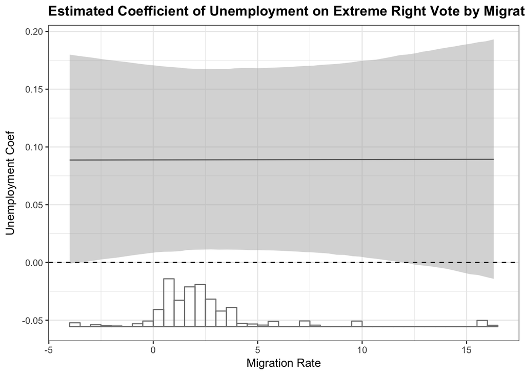

```r
library(interplot)
par(mfrow=c(1,2))
interplot(m = glm.fit, var1 = "sur", var2 = "migration", hist = TRUE) +
  # Add labels for X and Y axes
    xlab("Migration Rate") +
    ylab("Unemployment Coef") +
  # Change the background
    theme_bw() +
  # Add the title
    ggtitle("Estimated Coefficient of Unemployment on Extreme Right Vote by Migration") +
    theme(plot.title = element_text(face="bold")) +
  # Add a horizontal line at y = 0
    geom_hline(yintercept = 0, linetype = "dashed")
```

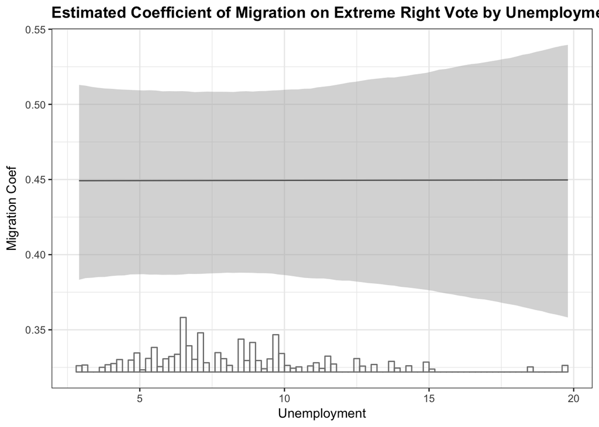

```r
interplot(m = glm.fit, var1 = "migration", var2 = "sur", hist = TRUE) +
  # Add labels for X and Y axes
    xlab("Unemployment") +
    ylab("Migration Coef") +
  # Change the background
    theme_bw() +
  # Add the title
    ggtitle("Estimated Coefficient of Migration on Extreme Right Vote by Unemployment") +
    theme(plot.title = element_text(face="bold"))
```

```r
par(mfrow=c(1,1))
```

## Simulation of increased Migration

Similar to what has been done by Arzheimer and Javed and Gidron we attempt to illustrate what happens if we keep all variables fixed and only increase the immigration variable from it’s minimum to it’s maximum. For all continuous variables we have chosen their mean, for variables with levels we choose the one connected to most likely ER vote, as these only determine the baseliine, but not the slope of the graph, due to no interactions with the migration variable.

The values picked by us predict a relatively high probability of voting for ER, but the impact of migration is almost linear and not especially strong.

```r
##Create means for all variables or set predetermined level.

means.mig <- c(0,1,0,0,1,0,0,0,0,1,-0.2823178,0.1254217,-0.09784655,4.614493,2.663593,0,8.295773,36.87453,5.586569,8.7076,16.40313,0)
names(means.mig) <- c("male","age1","age2","age4","mye1","mye2","farmerown","worker","retired","unemployed","zlrs","euschlecht","zsatisdmo","disp","lfed1","migration","sur","replacementrate","rmax","salienzmean","rvar","country")
means.mig$male = "nein"
```

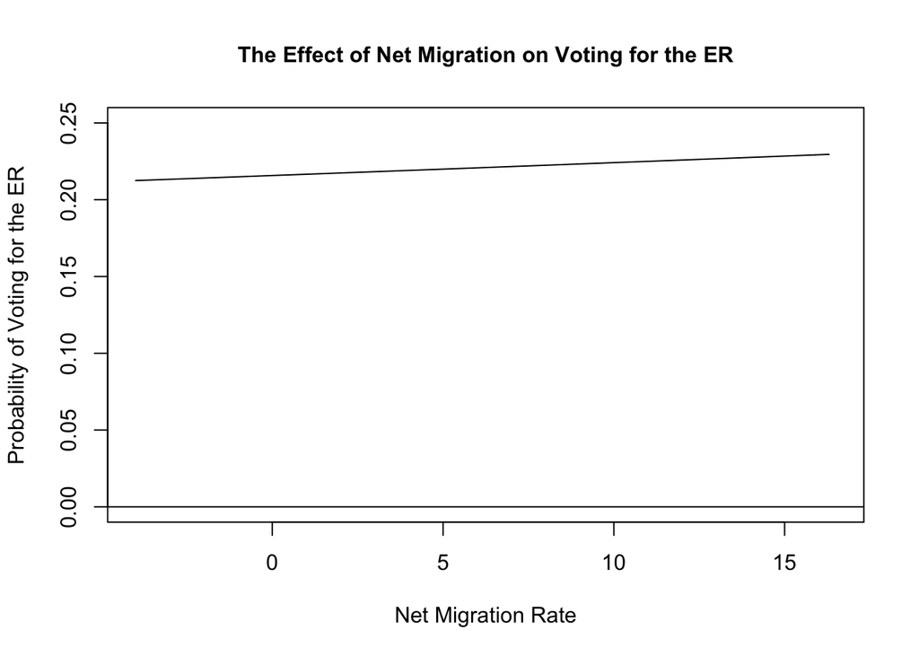

```r
means.mig$country = "IT"

##Simulate change in prob of ER vote due to change in net migration rate with all other variables held at mean.

mig <- seq(from = -4, to=16.3, by=.1)
ests.mig <- matrix(data=NA, ncol=length(mig) ,nrow=1)

for(j in 1:length(mig)){
  data.mig <- means.mig
    data.mig$migration <- mig[j]
    ests.mig[j] <- predict(glm.fit, type="response", newdata = data.mig)
    }

plot(NA,NA, ylim= c(0.0,.25),xlim=c(-4,16.5), xlab="Net Migration Rate", ylab="Probability of Voting for the ER", main="The Effect of Net Migration on Voting for the ER", cex.main=1)
lines(mig, ests.mig)
abline(h=0)
```

We conclude that overall our results do not look to different from what Arzheimer and the previous replication have identified. Due to lack of familiarity with some libraries used by the original author(s), we did not simulate the variance as they have done and thus have less detailed results, but were able to extract the gist of their graphics.